# Context & Objectives

**Context**

Certain businesses such as banks often need to have into consideration the element of 'Customer Churn' and contributing factors that might be affecting their overall retention rate with the primary goal of reducing the likelihood of an acquired customer leaving and joining a competitive service. For that, it is important to understand which aspects of the service influence a customer's decision in this regard, so that management can concentrate efforts on what it means to improve the service with these aspects in mind.

**Objective**

You as a Data scientist with the bank need to build a neural network based classifier that can determine whether a customer will leave the bank or not in the next 6 months.

# Data Dictonary

- CustomerId: Unique ID which is assigned to each customer
- Surname: Last name of the customer
- CreditScore: It defines the credit history of the customer
- Geography: A customer’s location
- Gender: It represents the Gender of the customer
- Age: Age of the customer
- Tenure: Number of years for which the customer has been with the bank
- NumOfProducts: refers to the number of products that a customer has purchased through the bank
- Balance: Account balance
- HasCrCard: A categorical variable representing whether a customer has credit
- EstimatedSalary: Estimated salary
- isActiveMember: A categorical variable representing whether a customer is an active member of the bank or not ( Active member in the sense, using bank products regularly, making transactions etc.)
- Exited: whether or not the customer left the bank within six month. It can take two values - 0=No ( Customer did not leave the bank ); 1=Yes ( Customer left the bank )

# Importing Libraries

```python
# Installing the libraries with the specified version.
!pip install tensorflow==2.15.0 scikit-learn==1.2.2 seaborn==0.13.1 matplotlib==3.7.1 numpy==1.25.2 pandas==2.0.3 imbalanced-learn==0.10.1 -q --user
```

Note: had to install Pandas 2.0.3 instead of 1.5.3 (as per previous project) to resolve google colab error message of outdated library

```python
# Library to support with data reading and manipulation
import pandas as pd
import numpy as np

# Library to support with data visualization
import matplotlib.pyplot as plt
import seaborn as sns
sns.set()

# Library to support with data spliting
from sklearn.model_selection import train_test_split

# Library to support with data scaling
from sklearn.preprocessing import StandardScaler, LabelEncoder

# Importing functions for model bulding
import tensorflow as tf #An end-to-end open source machine learning platform
from tensorflow import keras # High-level neural networks API for deep learning
from keras import backend # Abstraction layer for neural network backend engines
from keras.models import Sequential # Model for building NN sequentially
from keras.layers import Dense, Dropout

# importing SMOTE
from imblearn.over_sampling import SMOTE

# importing libraries
import time
from inspect import EndOfBlock

# importing metrics
from sklearn import metrics
from sklearn.metrics import (
    f1_score,
    accuracy_score,
    recall_score,
    precision_score,
    confusion_matrix,
    roc_auc_score,
    roc_curve,
    ConfusionMatrixDisplay,
    classification_report,
)

import random

# Library to avoid the warnings
import warnings
warnings.filterwarnings("ignore")
```

# Loading the Dataset

```python
# mounting the drive
from google.colab import drive
drive.mount('/content/drive')
```

```python
# reading the data
df = pd.read_csv("/content/drive/MyDrive/pgp_aiml/neural_networks/nn_churn.csv")
```

```python
# copying data to another variable to avoid any changes to original data
data = df.copy()
```

# Overview of the Dataset

#### First and Last 5 Rows & 10 Random Rows

```python
# viewing first 5 rows of the dataset
data.head()
```

|  | RowNumber | CustomerId | Surname | CreditScore | Geography | Gender | Age | Tenure | Balance | NumOfProducts | HasCrCard | IsActiveMember | EstimatedSalary | Exited |
| --- | --- | --- | --- | --- | --- | --- | --- | --- | --- | --- | --- | --- | --- | --- |
| 0 | 1 | 15634602 | Hargrave | 619 | France | Female | 42 | 2 | 0.00 | 1 | 1 | 1 | 101348.88 | 1 |
| 1 | 2 | 15647311 | Hill | 608 | Spain | Female | 41 | 1 | 83807.86 | 1 | 0 | 1 | 112542.58 | 0 |
| 2 | 3 | 15619304 | Onio | 502 | France | Female | 42 | 8 | 159660.80 | 3 | 1 | 0 | 113931.57 | 1 |
| 3 | 4 | 15701354 | Boni | 699 | France | Female | 39 | 1 | 0.00 | 2 | 0 | 0 | 93826.63 | 0 |
| 4 | 5 | 15737888 | Mitchell | 850 | Spain | Female | 43 | 2 | 125510.82 | 1 | 1 | 1 | 79084.10 | 0 |

```python
# viewing last 5 rows of the dataset
data.tail()
```

|  | RowNumber | CustomerId | Surname | CreditScore | Geography | Gender | Age | Tenure | Balance | NumOfProducts | HasCrCard | IsActiveMember | EstimatedSalary | Exited |
| --- | --- | --- | --- | --- | --- | --- | --- | --- | --- | --- | --- | --- | --- | --- |
| 9995 | 9996 | 15606229 | Obijiaku | 771 | France | Male | 39 | 5 | 0.00 | 2 | 1 | 0 | 96270.64 | 0 |
| 9996 | 9997 | 15569892 | Johnstone | 516 | France | Male | 35 | 10 | 57369.61 | 1 | 1 | 1 | 101699.77 | 0 |
| 9997 | 9998 | 15584532 | Liu | 709 | France | Female | 36 | 7 | 0.00 | 1 | 0 | 1 | 42085.58 | 1 |
| 9998 | 9999 | 15682355 | Sabbatini | 772 | Germany | Male | 42 | 3 | 75075.31 | 2 | 1 | 0 | 92888.52 | 1 |
| 9999 | 10000 | 15628319 | Walker | 792 | France | Female | 28 | 4 | 130142.79 | 1 | 1 | 0 | 38190.78 | 0 |

```python
# let's view a sample of the data
data.sample(n=10, random_state=1)
```

|  | RowNumber | CustomerId | Surname | CreditScore | Geography | Gender | Age | Tenure | Balance | NumOfProducts | HasCrCard | IsActiveMember | EstimatedSalary | Exited |
| --- | --- | --- | --- | --- | --- | --- | --- | --- | --- | --- | --- | --- | --- | --- |
| 9953 | 9954 | 15655952 | Burke | 550 | France | Male | 47 | 2 | 0.00 | 2 | 1 | 1 | 97057.28 | 0 |
| 3850 | 3851 | 15775293 | Stephenson | 680 | France | Male | 34 | 3 | 143292.95 | 1 | 1 | 0 | 66526.01 | 0 |
| 4962 | 4963 | 15665088 | Gordon | 531 | France | Female | 42 | 2 | 0.00 | 2 | 0 | 1 | 90537.47 | 0 |
| 3886 | 3887 | 15720941 | Tien | 710 | Germany | Male | 34 | 8 | 147833.30 | 2 | 0 | 1 | 1561.58 | 0 |
| 5437 | 5438 | 15733476 | Gonzalez | 543 | Germany | Male | 30 | 6 | 73481.05 | 1 | 1 | 1 | 176692.65 | 0 |
| 8517 | 8518 | 15671800 | Robinson | 688 | France | Male | 20 | 8 | 137624.40 | 2 | 1 | 1 | 197582.79 | 0 |
| 2041 | 2042 | 15709846 | Yeh | 840 | France | Female | 39 | 1 | 94968.97 | 1 | 1 | 0 | 84487.62 | 0 |
| 1989 | 1990 | 15622454 | Zaitsev | 695 | Spain | Male | 28 | 0 | 96020.86 | 1 | 1 | 1 | 57992.49 | 0 |
| 1933 | 1934 | 15815560 | Bogle | 666 | Germany | Male | 74 | 7 | 105102.50 | 1 | 1 | 1 | 46172.47 | 0 |
| 9984 | 9985 | 15696175 | Echezonachukwu | 602 | Germany | Male | 35 | 7 | 90602.42 | 2 | 1 | 1 | 51695.41 | 0 |

- The `RowNumber` column contains unique values
- The 'CustomerID' column contains unique values
- The 'Balance'column contains zero values
- The 'HasCrCard', 'IsActiveMember' and 'Exited' columns present binary values

#### Shape of the Dataset

```python
# getting the number of rows and columns
num_rows, num_columns = data.shape

# printing the result
print(f'The dataset has {num_rows} rows and {num_columns} columns.')
```

```
The dataset has 10000 rows and 14 columns.
```

#### Columns Data Types

```python
# using the info() function to display information about the DataFrame
data.info()
```

```
<class 'pandas.core.frame.DataFrame'>
RangeIndex: 10000 entries, 0 to 9999
Data columns (total 14 columns):
 #   Column           Non-Null Count  Dtype
---  ------           --------------  -----
 0   RowNumber        10000 non-null  int64
 1   CustomerId       10000 non-null  int64
 2   Surname          10000 non-null  object
 3   CreditScore      10000 non-null  int64
 4   Geography        10000 non-null  object
 5   Gender           10000 non-null  object
 6   Age              10000 non-null  int64
 7   Tenure           10000 non-null  int64
 8   Balance          10000 non-null  float64
 9   NumOfProducts    10000 non-null  int64
 10  HasCrCard        10000 non-null  int64
 11  IsActiveMember   10000 non-null  int64
 12  EstimatedSalary  10000 non-null  float64
 13  Exited           10000 non-null  int64
dtypes: float64(2), int64(9), object(3)
memory usage: 1.1+ MB
```

- 3 columns are object types, 2 are float types while 9 are integers
- At this stage, there's no indication of missing values

#### Converting Objects to Categories

```python
cols = data.select_dtypes(['object'])
cols.columns
```

```
Index(['Surname', 'Geography', 'Gender'], dtype='object')
```

```python
for i in cols.columns:
    data[i] = data[i].astype('category')
```

```python
data.info()
```

```
<class 'pandas.core.frame.DataFrame'>
RangeIndex: 10000 entries, 0 to 9999
Data columns (total 14 columns):
 #   Column           Non-Null Count  Dtype
---  ------           --------------  -----
 0   RowNumber        10000 non-null  int64
 1   CustomerId       10000 non-null  int64
 2   Surname          10000 non-null  category
 3   CreditScore      10000 non-null  int64
 4   Geography        10000 non-null  category
 5   Gender           10000 non-null  category
 6   Age              10000 non-null  int64
 7   Tenure           10000 non-null  int64
 8   Balance          10000 non-null  float64
 9   NumOfProducts    10000 non-null  int64
 10  HasCrCard        10000 non-null  int64
 11  IsActiveMember   10000 non-null  int64
 12  EstimatedSalary  10000 non-null  float64
 13  Exited           10000 non-null  int64
dtypes: category(3), float64(2), int64(9)
memory usage: 986.3 KB
```

#### Unique Categories

```python
cols_cat= data.select_dtypes(['category'])
```

```python
for i in cols_cat.columns:
    print('Unique values in',i, 'are :')
    print(cols_cat[i].value_counts())
    print('*'*50)
```

```
Unique values in Surname are :
Surname
Smith         32
Martin        29
Scott         29
Walker        28
Brown         26
              ..
Etheridge      1
Milliner       1
Milligan       1
Eva            1
Kuykendall     1
Name: count, Length: 2932, dtype: int64
Unique values in Geography are :
Geography
France     5014
Germany    2509
Spain      2477
Name: count, dtype: int64
Unique values in Gender are :
Gender
Male      5457
Female    4543
Name: count, dtype: int64
```

- We're observing some imbalance in the geography column, since there are more customers based in France that other parts of the world.

#### Unique Values

```python
# Observing unique values in each column of the dataset
data.nunique()
```

```
RowNumber          10000
CustomerId         10000
Surname             2932
CreditScore          460
Geography              3
Gender                 2
Age                   70
Tenure                11
Balance             6382
NumOfProducts          4
HasCrCard              2
IsActiveMember         2
EstimatedSalary     9999
Exited                 2
dtype: int64
```

#### Duplicate Values

```python
# checking for duplicate values
data.duplicated().sum()
```

```
0
```

There are no duplicate values in this dataset

#### Missing Values

```python
# checking for null values
data.isnull().sum()
```

```
RowNumber          0
CustomerId         0
Surname            0
CreditScore        0
Geography          0
Gender             0
Age                0
Tenure             0
Balance            0
NumOfProducts      0
HasCrCard          0
IsActiveMember     0
EstimatedSalary    0
Exited             0
dtype: int64
```

No missing values can be observed in this dataset

#### Dropping 'RowNumber' & 'Surname'

```python
# Dropping RowNumber and Surname columns
data = data.drop(['RowNumber', 'Surname'], axis=1)
```

- We've decided to drop 'RowNumber' and 'Surname' since these represent unique values and our aim is to mitigate multicolinearity in our model.
- We'll keep CustomerId for now simply to assist with EDA - we will be sure to drop it as we prepare data for modelling.

#### Statistical Summary

```python
# checking the statistical summary of the data
data.describe(include='all').T
```

|  | count | unique | top | freq | mean | std | min | 25% | 50% | 75% | max |
| --- | --- | --- | --- | --- | --- | --- | --- | --- | --- | --- | --- |
| CustomerId | 10000.0 | NaN | NaN | NaN | 15690940.5694 | 71936.186123 | 15565701.0 | 15628528.25 | 15690738.0 | 15753233.75 | 15815690.0 |
| CreditScore | 10000.0 | NaN | NaN | NaN | 650.5288 | 96.653299 | 350.0 | 584.0 | 652.0 | 718.0 | 850.0 |
| Geography | 10000 | 3 | France | 5014 | NaN | NaN | NaN | NaN | NaN | NaN | NaN |
| Gender | 10000 | 2 | Male | 5457 | NaN | NaN | NaN | NaN | NaN | NaN | NaN |
| Age | 10000.0 | NaN | NaN | NaN | 38.9218 | 10.487806 | 18.0 | 32.0 | 37.0 | 44.0 | 92.0 |
| Tenure | 10000.0 | NaN | NaN | NaN | 5.0128 | 2.892174 | 0.0 | 3.0 | 5.0 | 7.0 | 10.0 |
| Balance | 10000.0 | NaN | NaN | NaN | 76485.889288 | 62397.405202 | 0.0 | 0.0 | 97198.54 | 127644.24 | 250898.09 |
| NumOfProducts | 10000.0 | NaN | NaN | NaN | 1.5302 | 0.581654 | 1.0 | 1.0 | 1.0 | 2.0 | 4.0 |
| HasCrCard | 10000.0 | NaN | NaN | NaN | 0.7055 | 0.45584 | 0.0 | 0.0 | 1.0 | 1.0 | 1.0 |
| IsActiveMember | 10000.0 | NaN | NaN | NaN | 0.5151 | 0.499797 | 0.0 | 0.0 | 1.0 | 1.0 | 1.0 |
| EstimatedSalary | 10000.0 | NaN | NaN | NaN | 100090.239881 | 57510.492818 | 11.58 | 51002.11 | 100193.915 | 149388.2475 | 199992.48 |
| Exited | 10000.0 | NaN | NaN | NaN | 0.2037 | 0.402769 | 0.0 | 0.0 | 0.0 | 0.0 | 1.0 |

Numerical

- `CreditScore` ranges from a minimum of 350 to a max of 850 with an mean set at 650.5
- `Age` ranges from a minimum of 18 to a max of 92 with a mean set at 38.92
- `Tenure` ranges from 0 to 10 years with a mean set at 5
- `Balance` ranges from 0 to 250898.09 with a mean set at 76485.89
- `NumOfProducts` ranges from 1 to 4 with a mean set at 1.5
- `EstimatedSalary` ranges from 11.58 to 199992.48 with a mean set at 100090.23

Categorical

- `Geography` has 3 unique values with 'France' being the most prevalent value in the dastaset
- `Gender` is a binary column indicative of two unique categories 'Male' and 'Female' where 'Male' appears to be the most prevalent value in the dataset
- `HasCrCard`is a binary column indicative of two unique categories '0' and '1' representing whether a customer has or doesn't have a credit card - where having a credit card seeming to be the most commonly observed behavior
- `IsActiveMember` is a binary column indicative of two unique categories '0' and '1' representing whether a customer is an active member or not
- `Exited` is a binary column indicative of two unique categories '0' and '1' representing whether a customer left the bank within six months.

# Exploratory Data Analysis

## Univariate Analysis

#### Univariate Functions

```python
# function to plot a boxplot and a histogram along the same scale.


def histogram_boxplot(data, feature, figsize=(12, 7), kde=True, bins=False):
    """
    Boxplot and histogram combined

    data: dataframe
    feature: dataframe column
    figsize: size of figure (default (12,7))
    kde: whether to show the density curve (default False)
    bins: number of bins for histogram (default None)
    """
    f2, (ax_box2, ax_hist2) = plt.subplots(
        nrows=2,  # Number of rows of the subplot grid= 2
        sharex=True,  # x-axis will be shared among all subplots
        gridspec_kw={"height_ratios": (0.25, 0.75)},
        figsize=figsize,
    )  # creating the 2 subplots
    sns.boxplot(
        data=data, x=feature, ax=ax_box2, showmeans=True, color="violet"
    )  # boxplot will be created and a star will indicate the mean value of the column
    sns.histplot(
        data=data, x=feature, kde=kde, kde_kws={'bw_adjust': 0.5}, ax=ax_hist2, bins=bins, palette="winter"
    ) if bins else sns.histplot(
        data=data, x=feature, kde=kde, ax=ax_hist2
    )  # For histogram
    ax_hist2.axvline(
        data[feature].mean(), color="green", linestyle="--"
    )  # Add mean to the histogram
    ax_hist2.axvline(
        data[feature].median(), color="black", linestyle="-"
    )  # Add median to the histogram
```

```python
# function to create labeled barplots


def labeled_barplot(data, feature, perc=False, n=None):
    """
    Barplot with percentage at the top

    data: dataframe
    feature: dataframe column
    perc: whether to display percentages instead of count (default is False)
    n: displays the top n category levels (default is None, i.e., display all levels)
    """

    total = len(data[feature])  # length of the column
    count = data[feature].nunique()
    if n is None:
        plt.figure(figsize=(count + 1, 5))
    else:
        plt.figure(figsize=(n + 1, 5))

    plt.xticks(rotation=90, fontsize=12)
    ax = sns.countplot(
        data=data,
        x=feature,
        palette="Paired",
        order=data[feature].value_counts().index[:n].sort_values(),
    )

    for p in ax.patches:
        if perc == True:
            label = "{:.1f}%".format(
                100 * p.get_height() / total
            )  # percentage of each class of the category
        else:
            label = p.get_height()  # count of each level of the category

        x = p.get_x() + p.get_width() / 2  # width of the plot
        y = p.get_height()  # height of the plot

        ax.annotate(
            label,
            (x, y),
            ha="center",
            va="center",
            size=12,
            xytext=(0, 5),
            textcoords="offset points",
        )  # annotate the percentage

    plt.show()  # show the plot
```

#### Age

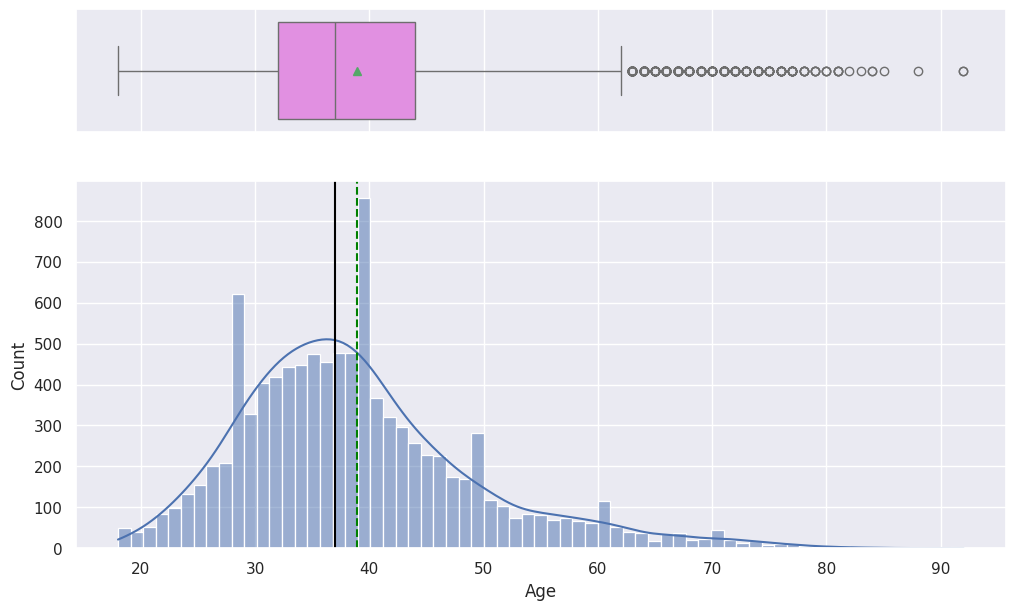

```python
# Generating an histogram and boxplot to observe distribution
histogram_boxplot(data,'Age')
```

- We're observing significant skeweness towards the right, with many outliers observed in the upper quartile.
- A higher percentage of clients is observed between the ages of 30 and 45 with a median set at 37yo.
- There's a lower percentage of clients above the age of 50, indicating a possible limitation with respects to this model against real world data.

#### Gender

```
Gender
Female    4543
Male      5457
Name: CustomerId, dtype: int64
```

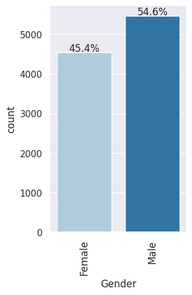

```python
# customer count for each group
gender_count = data.groupby('Gender')['CustomerId'].count()
print(gender_count)
print()

# Generating a barplot to observe distribution
labeled_barplot(data, "Gender", perc=True)
```

- We're observing a higher incidents of Male customers (54%) over Female customers (45%)

#### Geography

```
Geography
France     5014
Germany    2509
Spain      2477
Name: CustomerId, dtype: int64
```

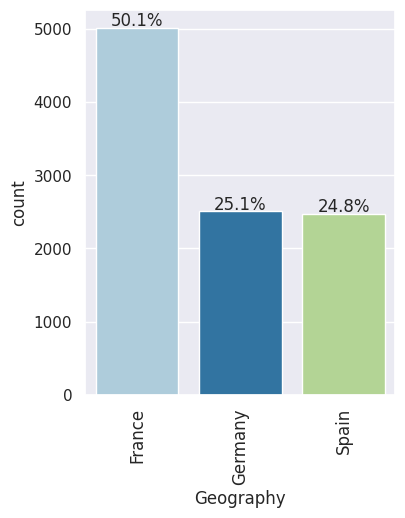

```python
# customer count for each group
geography_count = data.groupby('Geography')['CustomerId'].count()
print(geography_count)
print()

# Generating a barplot to observe distribution
labeled_barplot(data, "Geography", perc=True)
```

- We're observing a higher percentage of customers based in France (50%) compared to Germany (25%) and Spain (25%).
- This is an important element to consider when interpreting the results of the model.

#### Estimated Salary

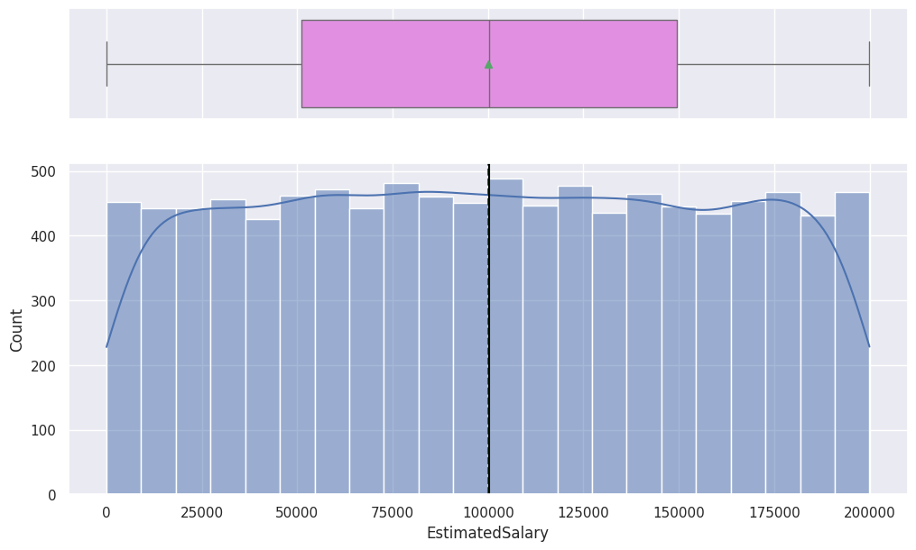

```python
# Generating an histogram and boxplot to observe distribution
histogram_boxplot(data,'EstimatedSalary')
```

- The histogram displays a uniform distribution, where the frequency of observations is roughly equal across the entire range of values.
- Each bin or interval in the histogram contains a similar number of observations, resulting in bars of approximately equal height.
- There's no observable skewness in the distribution.

#### Credit Score

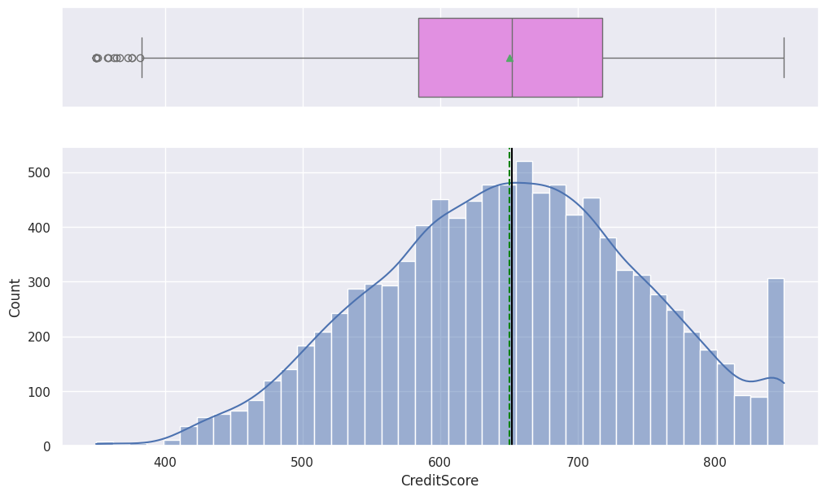

```python
# Generating an histogram and boxplot to observe distribution
histogram_boxplot(data,'CreditScore')
```

- We can observe a slight skewness towards the left, with some observable outliers on the lower quartile.
- The average credit score seems to sit around 650 - indicating that the average bank customer sits between a fair and good credit score.

#### Active Member

```
IsActiveMember
0    4849
1    5151
Name: CustomerId, dtype: int64
```

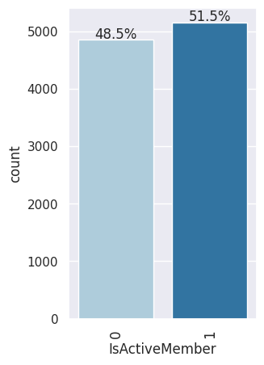

```python
# customer count for each group
membership_count = data.groupby('IsActiveMember')['CustomerId'].count()
print(membership_count)
print()

# Generating a barplot to observe distribution
labeled_barplot(data, "IsActiveMember", perc=True)
```

- We're observing a pretty interesting distribution in whether a customer is considered to be active or not active, with 51.5% of customers being labeled as 'active' and 48.5% labeled as 'inactive'.
- It will be interesting to explore the relationship of this variable with the likelihood of a customer churning.

#### Number of Products

```
NumOfProducts
1    5084
2    4590
3     266
4      60
Name: CustomerId, dtype: int64
```

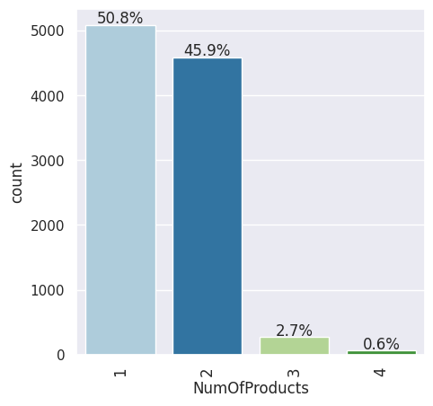

```python
# customer count for each group
products_count = data.groupby('NumOfProducts')['CustomerId'].count()
print(products_count)
print()

# Generating a barplot to observe distribution
labeled_barplot(data, "NumOfProducts", perc=True)
```

- The majority of the bank's customers seem to possess either 1 (51%) or 2 (46%) cards with only a little over 3% of customers possessing more than 2 cards.
- It will be interesting to explore if having more than 2 cards has any impact on the bank's retention rate.

#### Tenure

```
Tenure
0      413
1     1035
2     1048
3     1009
4      989
5     1012
6      967
7     1028
8     1025
9      984
10     490
Name: CustomerId, dtype: int64
```

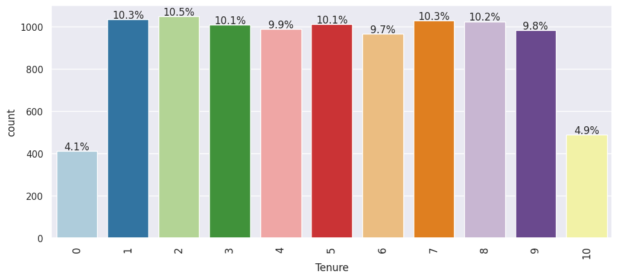

```python
# customer count for each group
tenure_count = data.groupby('Tenure')['CustomerId'].count()
print(tenure_count)
print()

# Generating a barplot to observe distribution
labeled_barplot(data, "Tenure", perc=True)
```

- We're observing a somehow uniform distribution, where the frequency of observations seems to be roughly equal across most range of values.
- Worth noting a much less customer incidence in zero and ten years of tenure, ponting to a potential likelihood of higher customer churn past 9 years and a potentially lower acquisition rate (year zero = new customers)

#### Balance

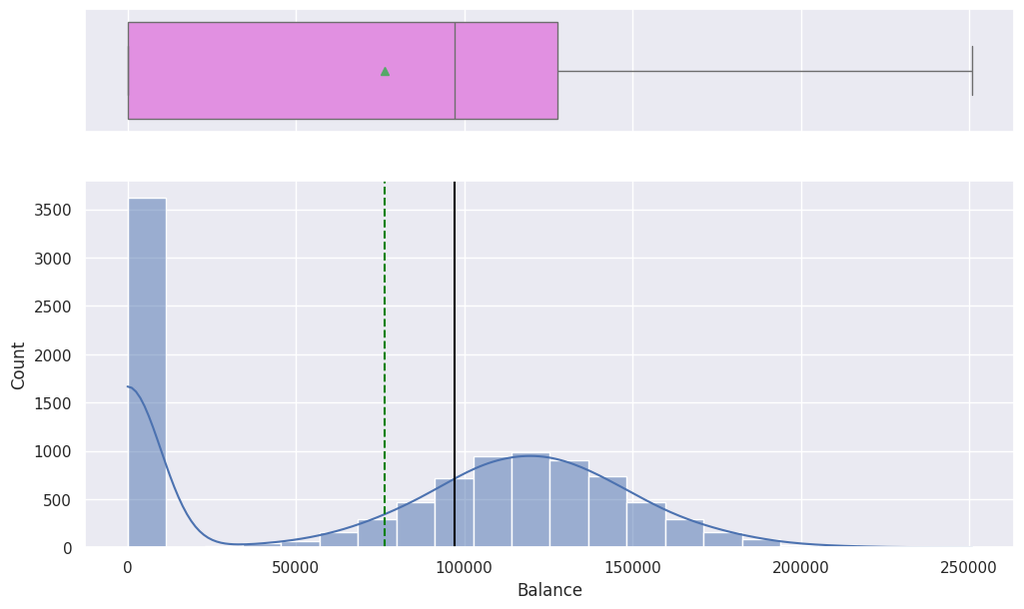

```python
# Generating an histogram and boxplot to observe distribution
histogram_boxplot(data,'Balance', kde=True)
```

- We're observing a right skewed distribution where over 25% of customers seem to have a balance of 0 USD with the remaining customer falling somewhere between 50k and 200k.
- It would be interesting to see if there's a potential relationship between customers with zero balance, our inactive customer count, customers with a credit card, and overall churn probability.

#### Credit Card

```
HasCrCard
0    2945
1    7055
Name: CustomerId, dtype: int64
```

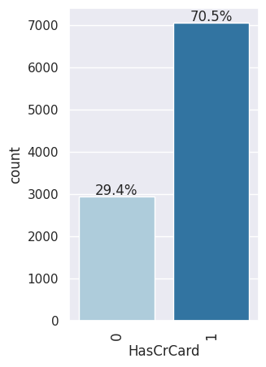

```python
# customer count for each group
ccard_count = data.groupby('HasCrCard')['CustomerId'].count()
print(ccard_count)
print()

# Generating a barplot to observe distribution
labeled_barplot(data, "HasCrCard", perc=True)
```

- We're observing a high percentage of bank customers with no credit credit (29.4%) compared to average, albeit still showing a majority of its customers (70.5%) to possess a credit card.
- It will be interesting to observe its relationship with overall probability of churn.

#### Exited

```
Exited
0    7963
1    2037
Name: CustomerId, dtype: int64
```

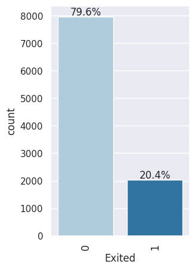

```python
# customer count for each group
exited_count = data.groupby('Exited')['CustomerId'].count()
print(exited_count)
print()

# Generating a barplot to observe distribution
labeled_barplot(data, "Exited", perc=True)
```

- We're observing a very high 20.4% churn rate at the bank, increasing the importance of further investigating the variables that best seem to contribute to this outcome.

## Bivariate Analysis

#### Bivariate Functions

```python
# function to plot stacked bar chart

def stacked_barplot(data, predictor, target):
    """
    Print the category counts and plot a stacked bar chart

    data: dataframe
    predictor: independent variable
    target: target variable
    """
    count = data[predictor].nunique()
    sorter = data[target].value_counts().index[-1]
    tab1 = pd.crosstab(data[predictor], data[target], margins=True).sort_values(
        by=sorter, ascending=False
    )
    print(tab1)
    print("-" * 120)
    tab = pd.crosstab(data[predictor], data[target], normalize="index").sort_values(
        by=sorter, ascending=False
    )
    tab.plot(kind="bar", stacked=True, figsize=(count + 1, 5))
    plt.xticks(rotation=45)
    plt.legend(
        loc="lower left", frameon=False,
    )
    plt.legend(loc="upper left", bbox_to_anchor=(1, 1))
    plt.show()
```

```python
### Function to plot distributions

def distribution_plot_wrt_target(data, predictor, target):

    fig, axs = plt.subplots(2, 2, figsize=(15, 10))

    target_uniq = data[target].unique()

    axs[0, 0].set_title("Distribution of target for target=" + str(target_uniq[0]))
    sns.histplot(
        data=data[data[target] == target_uniq[0]],
        x=predictor,
        kde=True,
        ax=axs[0, 0],
        color="teal",
    )

    axs[0, 1].set_title("Distribution of target for target=" + str(target_uniq[1]))
    sns.histplot(
        data=data[data[target] == target_uniq[1]],
        x=predictor,
        kde=True,
        ax=axs[0, 1],
        color="orange",
    )

    axs[1, 0].set_title("Boxplot w.r.t target")
    sns.boxplot(data=data, x=target, y=predictor, ax=axs[1, 0], palette="gist_rainbow")

    axs[1, 1].set_title("Boxplot (without outliers) w.r.t target")
    sns.boxplot(
        data=data,
        x=target,
        y=predictor,
        ax=axs[1, 1],
        showfliers=False,
        palette="gist_rainbow",
    )

    plt.tight_layout()
    plt.show()
```

#### Correlation

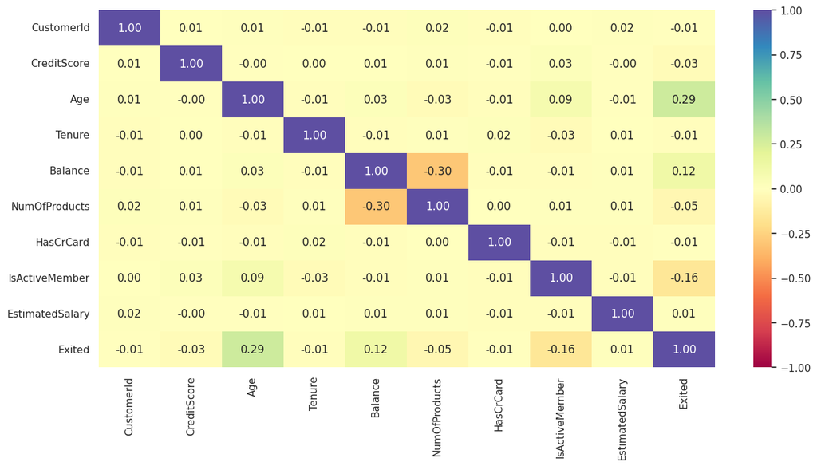

```python
plt.figure(figsize=(15, 7))
sns.heatmap(data.corr(numeric_only=True), annot=True, vmin=-1, vmax=1, fmt=".2f", cmap="Spectral")
plt.show()
```

Upon conducting a correlation matrix against all our columns, the following are the key takeaways we've observed:

- A weak positive correlation (0.29) between Age & Exited
- A weak positive correlation (0.12) between Balance & Exited
- A weak positive correlation (0.09) between IsActiveMember & Age
- A weak negative correlation (-0.05) between NumOfProducts & Exited
- A weak negative correlation (-0.16) between IsActiveMember & Exited
- A weak negative correlation (-0.30) between NumOfProdudcts & Balance

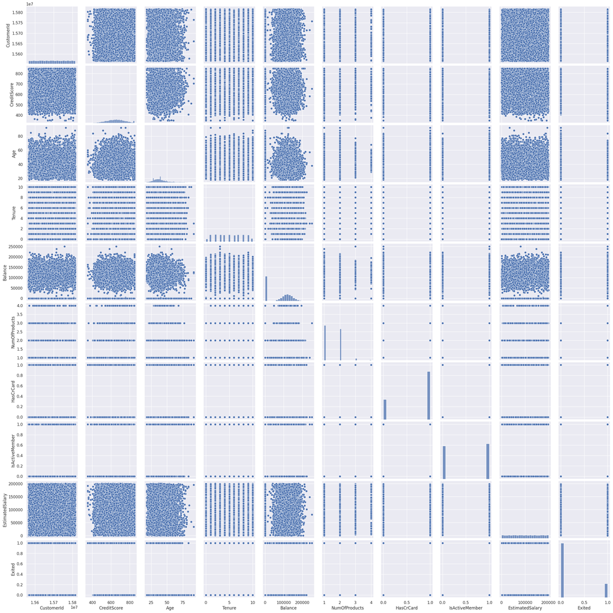

```python
sns.pairplot(data)
```

Conducting a SNS to help us further interpret the results of the correlation matrix:

- `Age & Exited` - We can observe a lower churn rate in customers above the age of 75yo
- `Balance & Exited` - We can observe a lower churn rate in customers with a balance above 200k
- `IsActiveMember & Age` - We're observing a lower incidence of active customers in those above the age of 80yo
- `NumOfProducts & Exited` - We can observe a higher churn rate in customers posessing 4 products
- `IsActiveMember & Exited` - Unable to correclty interpret results with the SNS, a stacked barplot will give us a more granular view into this data
- `NumOfProdudcts & Balance` - We can observe a somehow higher balance in customers who posess 1 or 2 products

#### Exited vs Age

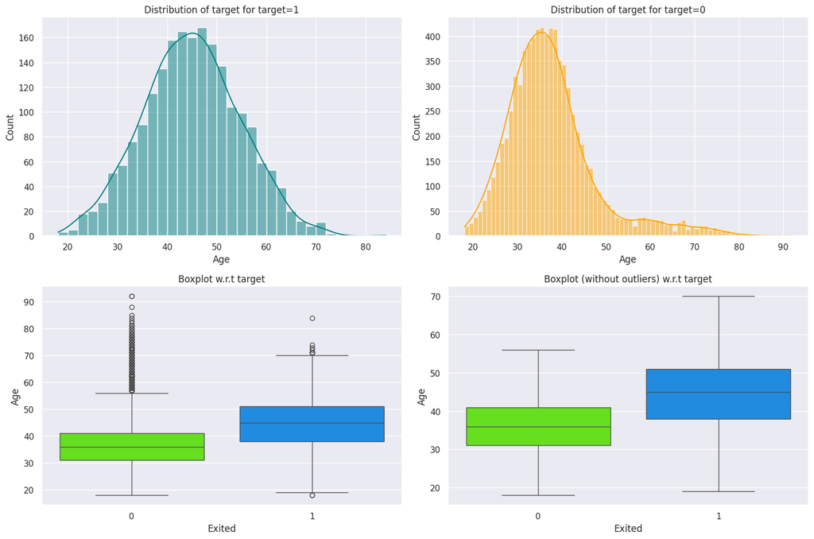

```python
# Creating a distribution of target plot
distribution_plot_wrt_target(data, "Age", "Exited")
```

- We can observe a higher attrition rate in customers whos age fall somewhere between late 30s and early 50s with a median set around 45yo.
- It's particular relevant to denote the proportionality - while the bank has a lower count of customer at the age of 50 we're still observing a higher churn rate for those in that age braket.

#### Exited vs Gender

```
Exited     0     1    All
Gender
All     7963  2037  10000
Female  3404  1139   4543
Male    4559   898   5457
------------------------------------------------------------------------------------------------------------------------
```

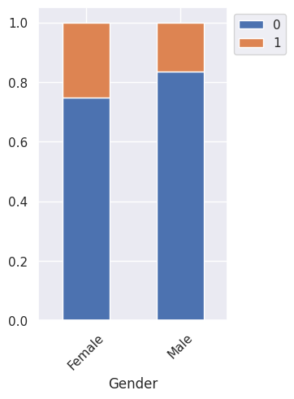

```python
# Creating a stacked barplot
stacked_barplot(data, "Gender", "Exited")
```

- Among Female customers, 1139 out of 4543 (25%) have attrited
- Among Male customers, 898 out of 5457 (16.45%) have attrited

These results suggest that female customers have a higher likelihood of exiting compared to male customers, indicating a potential gender-based difference in attrition patterns within the dataset. Further analysis may be needed to understand the underlying reasons for this difference and to develop targeted retention strategies.

#### Exited vs Geography

```
Exited        0     1    All
Geography
All        7963  2037  10000
Germany    1695   814   2509
France     4204   810   5014
Spain      2064   413   2477
------------------------------------------------------------------------------------------------------------------------
```

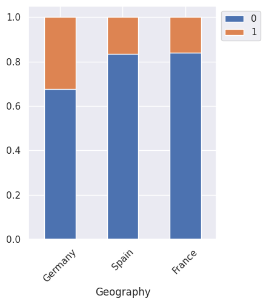

```python
# Creating a stacked barplot
stacked_barplot(data, "Geography", "Exited")
```

- Among German customers, 814 out of 2509 (32.44%) have attrited
- Among French customers, 810 out of 5014 (16.15%) have attrited
- Among Spanish customers, 413 out of 2477 (16.68%) have attrited

These results uncover Germany as the region presenting higher attrition rates compared to other regions covered by the bank.

#### Exited vs Estimated Salary

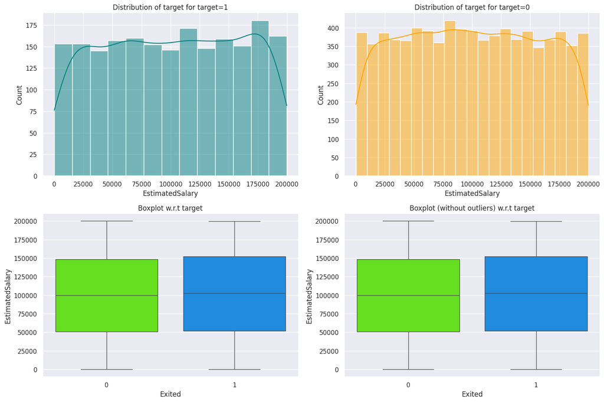

```python
# Creating a distribution of target plot
distribution_plot_wrt_target(data, "EstimatedSalary", "Exited")
```

- The distribution appears to behave quite similarly despite the introduction of the target variable. We're not seeing a significant impact of `Estimated Salary` on the target variable with a very minor uptake of exited customers between the 100k-125k mark and the 175k-200k mark.
- As observed in the correlation matrix, there's no observable positive or negatie correlation between `Estimated Salary` and the target variable.

#### Exited vs Credit Score

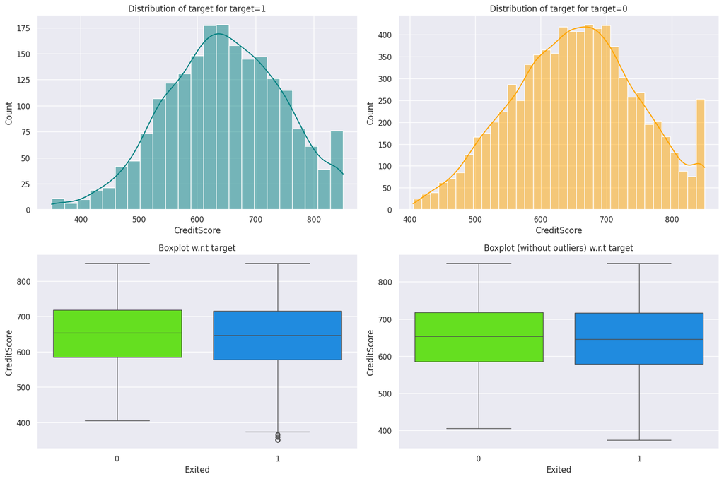

```python
# Creating a distribution of target plot
distribution_plot_wrt_target(data, "CreditScore", "Exited")
```

- Effects to the target variable seem to be minimal, we can however observe a somehow higher churn rate in customers with a credit score of 600

#### Exited vs Active Member

```
Exited             0     1    All
IsActiveMember
All             7963  2037  10000
0               3547  1302   4849
1               4416   735   5151
------------------------------------------------------------------------------------------------------------------------
```

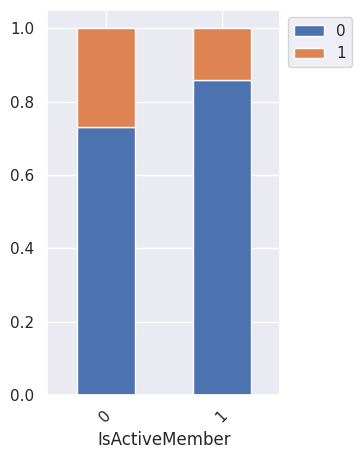

```python
# Creating a stacked barplot
stacked_barplot(data, "IsActiveMember", "Exited")
```

- Among customers who are not active, 1302 out of 4849 (26.87%) have attrited
- Among customers who are active, 735 out of 5151 (14.27%) have attrited

These results suggest that active membership status may have an impact on customer attrition rates, with non-active members exhibiting a higher likelihood of exiting. Further analysis may be needed to understand the underlying factors contributing to this difference and to develop targeted retention strategies for non-active members.

#### Exited vs Number of Products

```
Exited            0     1    All
NumOfProducts
All            7963  2037  10000
1              3675  1409   5084
2              4242   348   4590
3                46   220    266
4                 0    60     60
------------------------------------------------------------------------------------------------------------------------
```

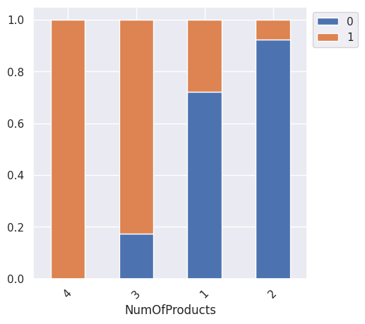

```python
# Creating a stacked barplot
stacked_barplot(data, "NumOfProducts", "Exited")
```

- Among customers with 1 product, 1409 out of 5084 (27.71%) have attrited
- Among customers with 2 products, 348 out of 4590 (7.58%) have attrited
- Among customers with 3 products, 220 out of 266 (82.71%) have attrited
- Among customers with 4 products, 60 out of 60 (100%) have attrited

These results suggest that the number of products held by a customer may have a significant impact on their likelihood of exiting, with a significantly higher attrition rate observe amongst customers with 3 or 4 products.

#### Exited vs Tenure

```
Exited     0     1    All
Tenure
All     7963  2037  10000
1        803   232   1035
3        796   213   1009
9        771   213    984
5        803   209   1012
4        786   203    989
2        847   201   1048
8        828   197   1025
6        771   196    967
7        851   177   1028
10       389   101    490
0        318    95    413
------------------------------------------------------------------------------------------------------------------------
```

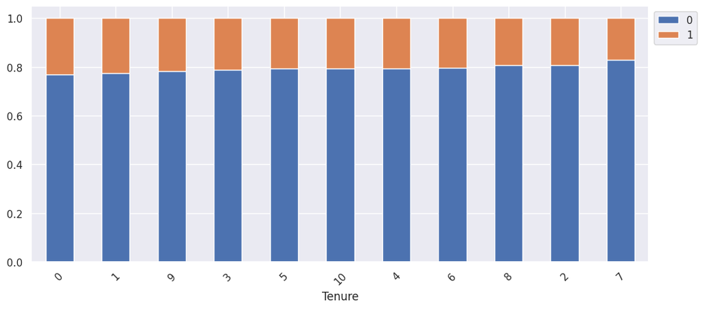

```python
# Creating a stacked barplot
stacked_barplot(data, "Tenure", "Exited")
```

- Among customers with 0 months tenure, 95 out of 413 (22.99%) have attrited
- Among customers with 1 month tenure, 232 out of 1035 (22.41%) have attrited
- Among customers with 2 months tenure, 201 out of 1048 (19.16%) have attrited
- Among customers with 3 months tenure, 213 out of 1009 (21.09%) have attrited
- Among customers with 4 months tenure, 203 out of 989 (20.52%) have attrited
- Among customers with 5 months tenure, 209 out of 1012 (20.65%) have attrited
- Among customers with 6 months tenure, 196 out of 967 (20.27%) have attrited
- Among customers with 7 months tenure, 177 out of 1028 (17.23%) have attrited
- Among customers with 8 months tenure, 197 out of 1025 (19.22%) have attrited
- Among customers with 9 months tenure, 213 out of 984 (21.65%) have attrited
- Among customers with 10 months tenure, 101 out of 490 (20.61%) have attrited

The overall attrition rate for all customers is approximately 20.37%. Attrition rates vary across different tenure lengths, with some months showing higher attrition rates than others.

New customers (with a tenure of 0 months) have a slightly higher attrition rate, indicating a potential challenge in retaining new customers during the initial period.

Worth observing that there's an observed decline in total customers holding a 10 month tenure indicating a potential rentention challenge past this period.

#### Exited vs Balance

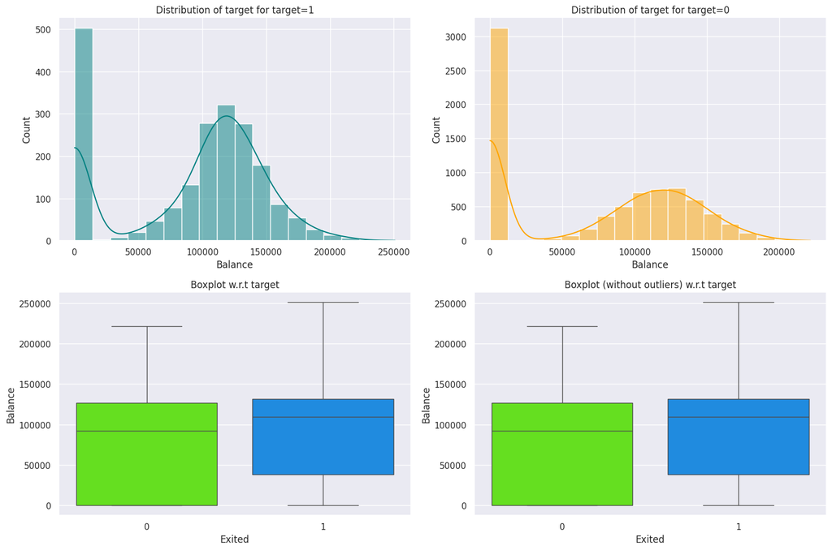

```python
# Creating a distribution of target plot
distribution_plot_wrt_target(data, "Balance", "Exited")
```

#### Exited vs Credit Card

```
Exited        0     1    All
HasCrCard
All        7963  2037  10000
1          5631  1424   7055
0          2332   613   2945
------------------------------------------------------------------------------------------------------------------------
```

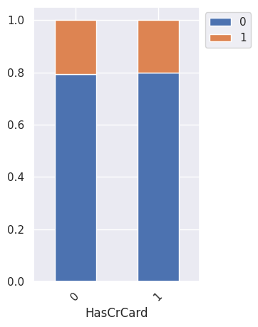

```python
# Creating a stacked barplot
stacked_barplot(data, "HasCrCard", "Exited")
```

- Among customers with a credit card, 1424 out of 7055 (20.19%) have attrited
- Among customers with no credit card, 613 out of 2945 (20.83%) have attrited

We're observing attrition rates in both the co-hort of customers with and those without a credit card, indicating a possible weak correlation between this variable and a customer exiting the bank. Further exploration will however be required for proper interpretation.

# Data Preprocessing

This dataset contains both numerical and categorical variables. We need to treat them first before we pass them onto the neural network. We will perform the below pre-processing steps:

- One hot encoding of categorical variables
- Scaling numerical variables

Before we scale numerical variables and encode categorical variables, we will first split the dataset into train and test datasets and perform these actions separately. This to ensure that the test set remains untouched during the preprocessing steps, preserving its integrity for evaluation; ensure it reflects a more realistic scenario where the model is trained on historical data and evaluated on unseen data; and reduce the possibility of data leakage.

#### Dropping ID Column

```python
# verifying total number of values under CustomerId
data.CustomerId.nunique()
```

```
10000
```

```python
# dropping CLIENTNUM column
data.drop(["CustomerId"], axis=1, inplace=True)
```

We've verified 10000 total CustomId counts and have decided to drop it since it becomes unessential for the purpose of this exercise.

#### Outlier Detection

```python
# Filter numerical columns
numerical_data = data.select_dtypes(include=['float64', 'int64'])

# Calculate quantiles for numerical columns only
Q1 = numerical_data.quantile(0.25)  # To find the 25th percentile
Q3 = numerical_data.quantile(0.75)  # To find the 75th percentile

IQR = Q3 - Q1  # Interquartile Range (75th percentile - 25th percentile)

# Finding lower and upper bounds for all numerical values
lower = (Q1 - 1.5 * IQR)
upper = (Q3 + 1.5 * IQR)
```

```python
# checking the % outliers
((data.select_dtypes(include=["float64", "int64"]) < lower) | (data.select_dtypes(include=["float64", "int64"]) > upper)).sum() / len(data) * 100
```

```
CreditScore         0.15
Age                 3.59
Tenure              0.00
Balance             0.00
NumOfProducts       0.60
HasCrCard           0.00
IsActiveMember      0.00
EstimatedSalary     0.00
Exited             20.37
dtype: float64
```

The above analysis points to the following observations:

- `CreditScore` outliers - 0.15%
- `Age` outliers - 3.59%
- `NumOfProducts` outliers - 0.6%
- `Exited` outliers - 20.37%
- We can observe quite a few outliers in the dataset across some of our columns.
- After careful consideration around the nature of our data, the reason why these outliers exit, the value they provide and the type of model we're using for this project, we've decided to not perform any outlier treatment or transformation as we've determined these to be proper values.

#### Train-Validation-Test Split

```python
# creating a copy of the dataframe
data1 = data.copy()
```

```python
# Dividing train data into X and y
X = data1.drop(['Exited'],axis=1)
y = data1['Exited']
```

```python
# Splitting data into 80% train and 20% temporary set
X_train, X_temp, y_train, y_temp = train_test_split(X, y, test_size=0.2, random_state=42, stratify=y, shuffle = True)

# Splitting temporary set into 75% test and 25% validation set
X_test, X_val, y_test, y_val = train_test_split(X_temp, y_temp, test_size=0.25, random_state=42, stratify=y_temp, shuffle = True)
```

```python
# printing the shape of the dataset
print(X_train.shape, X_val.shape, X_test.shape)
print() # introducing a line break
print(y_train.shape, y_val.shape, y_test.shape)
```

```
(8000, 10) (500, 10) (1500, 10)

(8000,) (500,) (1500,)
```

- We have 10k data points allowing us to split the data into train, validation and test for proper representation of the dataset.
- Opting for a 75:25 split as it offers a larger test set for more reliable assessment of model generalization - however understanding the trade-off where it may result in less reliable estimates of model performance on the validation set.
- Setting `shuffle` parameter to true to ensure data is randomly shuffled before splitting, helping prevent any inherent order or patterns in the data from biasing the splits.

#### Dummy Variable Creation

```python
# One-hot encoding creating dummy variables for 'Geography' and 'Gender' variables
X_train = pd.get_dummies(X_train, columns=["Geography","Gender"],drop_first=True)
X_test = pd.get_dummies(X_test, columns=["Geography","Gender"],drop_first=True)
X_val = pd.get_dummies(X_val, columns=["Geography","Gender"],drop_first=True)
```

```python
# printing the shape of the dataset
print(X_train.shape, X_val.shape, X_test.shape)
```

```
(8000, 11) (500, 11) (1500, 11)
```

- The variables "geography" and "gender" are typically considered nominal variables as they represent categories without an inherent order or hierarchy. Therefore, it's not necessary to use LabelEncoder to encode these variables before applying one-hot encoding. This ensures that the model treats each category as a separate and independent feature without imposing any ordinal relationships.
- In this code snippet, `drop='first'` is used to drop the first category in each variable to avoid multicollinearity (i.e., the "dummy variable trap").

#### Data Scaling

```python
# defining the list of columns to normalize
cols_list = ["CreditScore","Age","Tenure","Balance","EstimatedSalary"]

# creating an instance of the standard scaler
sc = StandardScaler()

# fitting the scaler on training data and transforming training, validation, and test data
X_train[cols_list] = sc.fit_transform(X_train[cols_list])
X_val[cols_list] = sc.transform(X_val[cols_list])  # Applying transform only, no need to fit again on validation set
X_test[cols_list] = sc.transform(X_test[cols_list])  # Applying transform only, no need to fit again on test set
```

**Scaling Technique**

- Due to the presence of outliers in the variables being scaled, we have put some consideration into whether there's value in using a more robust scaling technique such as RobustScaling. Despite potential benefits against outliers, we found that the risk of loss of information due to compression and potential distortion of the relationship between features were elements that didn't quite fit the needs and nature of our dataset.
- Between normalization vs standardization, we've opted for stardization as its approach better aligns with the nature of our data.

**Parameters**

- For validation and test sets, we're only applying the transform method of the StandardScaler, ensuring that these are scaled using the mean and standard deviation learned from the training data without re-estimating them.

```python
# validating changes in the dataset
X_train.head()
```

|  | CreditScore | Age | Tenure | Balance | NumOfProducts | HasCrCard | IsActiveMember | EstimatedSalary | Geography_Germany | Geography_Spain | Gender_Male |
| --- | --- | --- | --- | --- | --- | --- | --- | --- | --- | --- | --- |
| 2151 | 1.058568 | 1.715086 | 0.684723 | -1.226059 | 1 | 1 | 0 | 1.042084 | False | False | True |
| 8392 | 0.913626 | -0.659935 | -0.696202 | 0.413288 | 1 | 1 | 0 | -0.623556 | True | False | True |
| 5006 | 1.079274 | -0.184931 | -1.731895 | 0.601687 | 2 | 1 | 1 | 0.308128 | True | False | False |
| 4117 | -0.929207 | -0.184931 | -0.005739 | -1.226059 | 2 | 1 | 0 | -0.290199 | False | False | True |
| 7182 | 0.427035 | 0.955079 | 0.339492 | 0.548318 | 2 | 0 | 1 | 0.135042 | True | False | True |

#### Utility Functions

```python
def plot(history, name):
    """
    Function to plot loss/accuracy

    history: an object which stores the metrics and losses.
    name: can be one of Loss or Accuracy
    """
    fig, ax = plt.subplots() #Creating a subplot with figure and axes.
    plt.plot(history.history[name]) #Plotting the train accuracy or train loss
    plt.plot(history.history['val_'+name]) #Plotting the validation accuracy or validation loss

    plt.title('Model ' + name.capitalize()) #Defining the title of the plot.
    plt.ylabel(name.capitalize()) #Capitalizing the first letter.
    plt.xlabel('Epoch') #Defining the label for the x-axis.
    fig.legend(['Train', 'Validation'], loc="outside right upper") #Defining the legend, loc controls the position of the legend.
```

This function is useful for visualizing the training progress and monitoring for overfitting or underfitting during the training of machine learning models, particularly neural networks trained with frameworks like Keras.

```python
# defining a function to compute different metrics to check performance of a classification model built using statsmodels
def model_performance_classification(
    model, predictors, target, threshold=0.5
):
    """
    Function to compute different metrics to check classification model performance

    model: classifier
    predictors: independent variables
    target: dependent variable
    threshold: threshold for classifying the observation as class 1
    """

    # checking which probabilities are greater than threshold
    pred = model.predict(predictors) > threshold
    # pred_temp = model.predict(predictors) > threshold
    # # rounding off the above values to get classes
    # pred = np.round(pred_temp)

    acc = accuracy_score(target, pred)  # to compute Accuracy
    recall = recall_score(target, pred, average='weighted')  # to compute Recall
    precision = precision_score(target, pred, average='weighted')  # to compute Precision
    f1 = f1_score(target, pred, average='weighted')  # to compute F1-score

    # creating a dataframe of metrics
    df_perf = pd.DataFrame(
        {"Accuracy": acc, "Recall": recall, "Precision": precision, "F1 Score": f1,},
        index=[0],
    )

    return df_perf
```

This function is useful for quantitatively assessing the classification model's performance using multiple metrics. It allows for the evaluation of how well the model is performing in terms of correctly classifying instances into different classes and provides insights into its strengths and weaknesses.

# Model Building

#### Model Evaluation Criterion

**Potential Wrong Prediction**

- Predicting a customer will attrite when in reality, they won't (FP)
- Predicting a customer will not attrite, when in reality they will (FN)

**What Scenario is most relevant to the business?**

- If we predict that a customer will not attrite when in reality they would, then the company would have suffered the loss of a customer

**How can we reduce the impact?** We want the recall to be maximized. The greater the recall score, the higher are the chances of minimizing False Negatives.

```python
def make_confusion_matrix(actual_targets, predicted_targets):
    """
    To plot the confusion_matrix with percentages

    actual_targets: actual target (dependent) variable values
    predicted_targets: predicted target (dependent) variable values
    """
    cm = confusion_matrix(actual_targets, predicted_targets)
    labels = np.asarray(
        [
            ["{0:0.0f}".format(item) + "\n{0:.2%}".format(item / cm.flatten().sum())]
            for item in cm.flatten()
        ]
    ).reshape(cm.shape[0], cm.shape[1])

    plt.figure(figsize=(6, 4))
    sns.heatmap(cm, annot=labels, fmt="")
    plt.ylabel("True label")
    plt.xlabel("Predicted label")
```

```python
def plot(history, metric):
    """
    Function to plot loss/recall

    history: an object which stores the metrics and losses.
    metric: the metric to plot, either 'loss' or 'recall'
    """
    fig, ax = plt.subplots() # Creating a subplot with figure and axes.
    plt.plot(history.history[metric]) # Plotting the train metric
    plt.plot(history.history['val_' + metric]) # Plotting the validation metric

    plt.title('Model ' + metric.capitalize()) # Defining the title of the plot.
    plt.ylabel(metric.capitalize()) # Defining the label for the y-axis.
    plt.xlabel('Epoch') # Defining the label for the x-axis.
    fig.legend(['Train', 'Validation'], loc="outside right upper") # Defining the legend, loc controls the position of the legend.
```

```python
def print_loss(history):
    """
    Function to print training and validation loss.

    history: history object returned by model.fit()
    """
    train_loss = history.history['loss']
    val_loss = history.history['val_loss']

    for epoch, (train_loss_value, val_loss_value) in enumerate(zip(train_loss, val_loss), 1):
        print(f"Epoch {epoch}: Train Loss: {train_loss_value}, Validation Loss: {val_loss_value}")
```

```python
# creating a separate dataframe to store all of our recall scores for each model
train_metric_df = pd.DataFrame(columns=["recall"])
valid_metric_df = pd.DataFrame(columns=["recall"])
```

```python
# defining the batch size and # epochs upfront as we'll be using the same values for all models
batch_size = X_train.shape[0]
epochs = 10
```

- Given the size of our dataset, we're setting the batch size to the number of samples within our traning dataset
- We've experimented with a different number of epochs and 10 is the number that outputed better results. We're setting the same number of epochs for all models to ensure consistency and reproducibility.

##### Tensorflow Adaptations

```python
# convering bool columns to float64 as tensor was returning an error with boolean columns

bool_columns = ["Geography_Germany", "Geography_Spain", "Gender_Male"]
X_train[bool_columns] = X_train[bool_columns].astype("float64")
X_val[bool_columns] = X_val[bool_columns].astype("float64")
X_test[bool_columns] = X_test[bool_columns].astype("float64")
```

```python
# Convert NumPy arrays to TensorFlow tensors
X_train_tensor = tf.convert_to_tensor(X_train, dtype=tf.float32)
y_train_tensor = tf.convert_to_tensor(y_train, dtype=tf.float32)

# Similarly, convert validation and test data
X_val_tensor = tf.convert_to_tensor(X_val, dtype=tf.float32)
y_val_tensor = tf.convert_to_tensor(y_val, dtype=tf.float32)

X_test_tensor = tf.convert_to_tensor(X_test, dtype=tf.float32)
y_test_tensor = tf.convert_to_tensor(y_test, dtype=tf.float32)
```

- There was a conflict with tensoflow and boolean columns. I've proceeded to convert them to float64
- Similarly, conversion to tensors was required before model fitting

#### SGD Optimizer

##### Model Architecture

```python
# clearing the current Keras session, resetting all layers and models previously created, freeing up memory and resources.
tf.keras.backend.clear_session()
```

```python
# setting random seeds to ensure consistent and reproducible results
np.random.seed(2)
random.seed(2)
tf.random.set_seed(2)
```

```python
# returning the number of features in our training data
X_train.shape[1]
```

```
11
```

```python
#Initializing the neural network
model_0 = Sequential()
model_0.add(Dense(11,activation="relu",input_dim=X_train.shape[1]))
model_0.add(Dense(7,activation="relu"))
model_0.add(Dense(1,activation="sigmoid"))
```

- We've set the input layer to 11 neurons which corresponds to the number of features in our training data and setting the hidden layer 7 neurons as moderate number to start things off.
- We've chose ReLU (Rectified Linear Unit) as our activation function for its simplicity and effectiveness in deep learning. It introduces non-linearity to the network, enabling it to learn complex patterns in the data.
- The output layer has a single neuron with a sigmoid activation function (activation="sigmoid"). The sigmoid activation function squashes the output to the range [0, 1], making it suitable for binary classification tasks where the model needs to output probabilities of belonging to a particular class.

```python
# outputting the model summary
model_0.summary()
```

```
Model: "sequential"
_________________________________________________________________
 Layer (type)                Output Shape              Param #
=================================================================
 dense (Dense)               (None, 11)                132

 dense_1 (Dense)             (None, 7)                 84

 dense_2 (Dense)             (None, 1)                 8

=================================================================
Total params: 224 (896.00 Byte)
Trainable params: 224 (896.00 Byte)
Non-trainable params: 0 (0.00 Byte)
_________________________________________________________________
```

##### Model Compilation

```python
from tensorflow.keras.metrics import Recall

# compiling the model
optimizer = tf.keras.optimizers.SGD()    # defining SGD as the optimizer to be used
model_0.compile(loss='binary_crossentropy', optimizer=optimizer, metrics=[Recall()]) # defining binary crossentropy as the loss function
```

- Binary cross-entropy is specifically designed for binary classification problems. It measures the difference between probability distributions of two classes, making it well-suited for models that output probabilities for each class (such as sigmoid activation in the output layer for binary classification).
- Additionally, its convexity and differentiability makes it suitable for optimization using gradient-based methods like stochastic gradient descent (SGD).
- Lastly, the use of logarithms in the calculation penalizes confidently wrong predictions more heavily than predictions that are only slightly off. This property encourages the model to output well-calibrated probabilities, which is important for tasks like binary classification.

```python
start = time.time()

# fitting the model
history_0 = model_0.fit(
    X_train,
    y_train,
    validation_data = (X_val, y_val),
    batch_size = batch_size,
    epochs = epochs,
    verbose = 1,
)
end = time.time()

print(f"Training time: {end - start}")
```

```
Training time: 1.3171632289886475
```

##### Model Evaluation

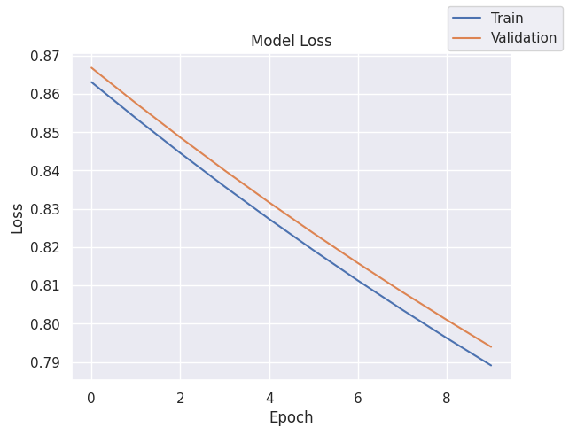

```python
plot(history_0, 'loss')
```

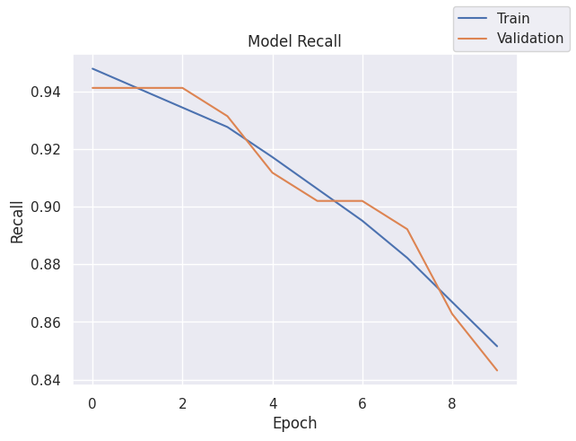

```python
plot(history_0, 'recall')
```

```python
#Predicting the results using best as a threshold
y_train_pred_sgd = model_0.predict(X_train)
y_train_pred_sgd = (y_train_pred_sgd > 0.5)
y_train_pred_sgd
```

```
array([[ True],
       [ True],
       [ True],
       ...,
       [ True],
       [False],
       [ True]])
```

```python
#Predicting the results using best as a threshold
y_val_pred_sgd = model_0.predict(X_val)
y_val_pred_sgd = (y_val_pred_sgd > 0.5)
np.set_printoptions(threshold=10) # limit the threshold of the output
y_val_pred_sgd
```

```
array([[ True],
       [ True],
       [ True],
       ...,
       [False],
       [ True],
       [ True]])
```

```python
# classification report
cr_sgd_train = classification_report(y_train, y_train_pred_sgd)
print(cr_sgd_train)
```

```
              precision    recall  f1-score   support

           0       0.65      0.08      0.14      6370
           1       0.19      0.83      0.31      1630

    accuracy                           0.23      8000
   macro avg       0.42      0.45      0.23      8000
weighted avg       0.55      0.23      0.18      8000
```

```python
# classification report
cr_sgd_val = classification_report(y_val, y_val_pred_sgd)
print(cr_sgd_val)
```

```
              precision    recall  f1-score   support

           0       0.69      0.09      0.16       398
           1       0.19      0.84      0.31       102

    accuracy                           0.24       500
   macro avg       0.44      0.47      0.24       500
weighted avg       0.59      0.24      0.19       500
```

```
None
```

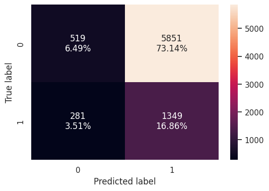

```python
cm_sgd_train = make_confusion_matrix(y_train, y_train_pred_sgd)
print(cm_sgd_train)
```

```
None
```

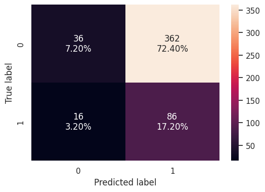

```python
cm_sgd_val = make_confusion_matrix(y_val, y_val_pred_sgd)
print(cm_sgd_val)
```

- While the model demonstrates strong recall for positive instances, it struggles with recall for negative instances, resulting in an overall imbalance in performance between the two classes.
- Further optimization or exploration of different model architectures may be necessary to improve recall for both classes and achieve a better balance in performance.

```python
model_name = "NN with SGD"

train_metric_df.loc[model_name] = recall_score(y_train, y_train_pred_sgd)
valid_metric_df.loc[model_name] = recall_score(y_val, y_val_pred_sgd)
```

# Model Performance Improvement

#### Adam Optimizer

##### Model Architecture

```python
# clears the current Keras session, resetting all layers and models previously created, freeing up memory and resources.
tf.keras.backend.clear_session()
```

```python
# setting random seeds to ensure consistent and reproducible results
np.random.seed(2)
random.seed(2)
tf.random.set_seed(2)
```

```python
#Initializing the neural network
model_1 = Sequential()
model_1.add(Dense(11,activation="relu",input_dim=X_train.shape[1]))
model_1.add(Dense(7,activation="relu"))
model_1.add(Dense(1,activation="sigmoid"))
```

- We've set the input layer to 11 neurons which corresponds to the number of features in our training data and again setting the hidden layer 7 neurons as moderate number to start things off.
- Again, we've chosen ReLU (Rectified Linear Unit) as our activation function for its simplicity and effectiveness in deep learning.
- The output layer has a single neuron with a sigmoid activation function (activation="sigmoid").

```python
# outputting the model summary
model_1.summary()
```

```
Model: "sequential"
_________________________________________________________________
 Layer (type)                Output Shape              Param #
=================================================================
 dense (Dense)               (None, 11)                132

 dense_1 (Dense)             (None, 7)                 84

 dense_2 (Dense)             (None, 1)                 8

=================================================================
Total params: 224 (896.00 Byte)
Trainable params: 224 (896.00 Byte)
Non-trainable params: 0 (0.00 Byte)
_________________________________________________________________
```

##### Model Compilation

```python
from tensorflow.keras.metrics import Recall

# compiling the model
optimizer = tf.keras.optimizers.Adam()    # defining adam as the optimizer to be used
model_1.compile(loss='binary_crossentropy', optimizer=optimizer, metrics=[Recall()]) # defining binary crossentropy as the loss function
```

- We're now experimenting with Adam as the optimizer
- We're persisting with binary_crossentropy to ensure consistency and reproducibility across models - we want to isolate the variance to ensure we identify the elements that best support this model's improvement

```python
start = time.time()

# fitting the model
history_1 = model_1.fit(
    X_train,
    y_train,
    validation_data = (X_val, y_val),
    batch_size = batch_size,
    epochs = epochs,
    verbose = 1,
)
end = time.time()

print(f"Training time: {end - start}")
```

```
Training time: 2.099372386932373
```

##### Model Evaluation

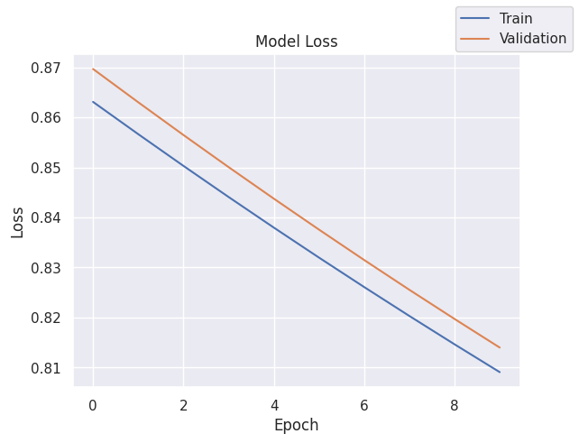

```python
plot(history_1, 'loss')
```

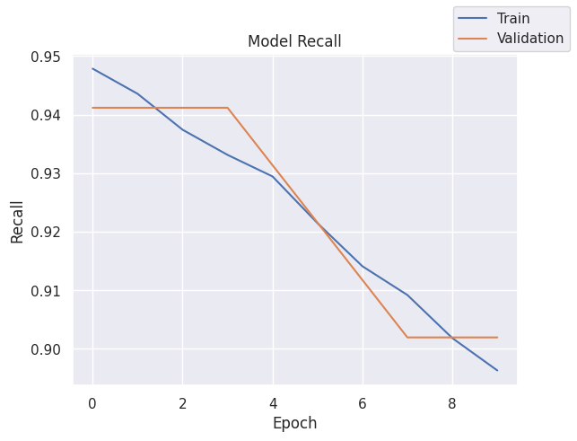

```python
plot(history_1, 'recall')
```

```python
#Predicting the results using best as a threshold
y_train_pred_adam = model_1.predict(X_train)
y_train_pred_adam = (y_train_pred_adam > 0.5)
y_train_pred_adam
```

```
array([[ True],
       [ True],
       [ True],
       ...,
       [ True],
       [ True],
       [ True]])
```

```python
#Predicting the results using best as a threshold
y_val_pred_adam = model_1.predict(X_val)
y_val_pred_adam = (y_val_pred_adam > 0.5)
y_val_pred_adam
```

```
array([[ True],
       [ True],
       [ True],
       ...,
       [False],
       [ True],
       [ True]])
```

```python
# classification report
cr_adam_train = classification_report(y_train, y_train_pred_adam)
print(cr_adam_train)
```

```
              precision    recall  f1-score   support

           0       0.63      0.05      0.09      6370
           1       0.19      0.89      0.32      1630

    accuracy                           0.22      8000
   macro avg       0.41      0.47      0.20      8000
weighted avg       0.54      0.22      0.14      8000
```

- Recall: The model achieves a recall of 0.89 for the positive class (1), indicating that it correctly identifies 89% of the positive instances in the training data. This suggests that the model is effective at capturing instances of the positive class.
- Precision: The precision for the positive class is 0.19, implying that when the model predicts a positive instance, it is correct only 19% of the time.
- Overall: While the recall for the positive class is relatively high, the overall performance metrics, including accuracy and F1-score, are low. This suggests that the model struggles to generalize well to the training data.

```python
# classification report
cr_adam_val = classification_report(y_val, y_val_pred_adam)
print(cr_adam_val)
```

```
              precision    recall  f1-score   support

           0       0.57      0.03      0.06       398
           1       0.19      0.90      0.32       102

    accuracy                           0.21       500
   macro avg       0.38      0.47      0.19       500
weighted avg       0.49      0.21      0.11       500
```

- Recall: Similar to the training set, the model achieves a high recall of 0.90 for the positive class in the validation set, indicating its ability to correctly identify positive instances.
- Precision: The precision being low indicates to although it has a high recall capacity, it may not be precise in its identification.
- Overall: The recall remains high on the validation set, suggesting that the model generalizes well to unseen data in terms of capturing positive instances. However, the overall performance metrics are low, indicating potential issues with model generalization and false positive predictions.

```
None
```

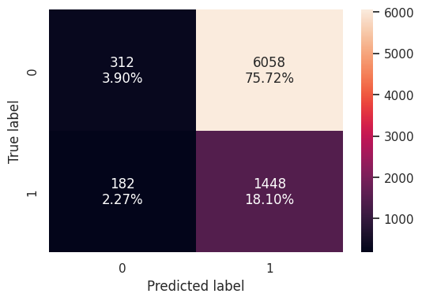

```python
cm_adam_train = make_confusion_matrix(y_train, y_train_pred_adam)
print(cm_adam_train)
```

```
None
```

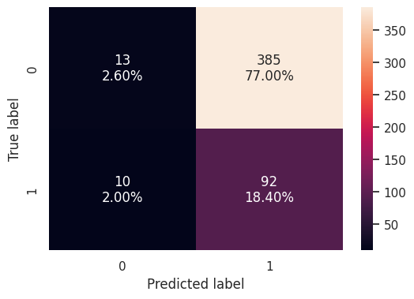

```python
cm_adam_val = make_confusion_matrix(y_val, y_val_pred_adam)
print(cm_adam_val)
```

In summary, while the model demonstrates strong recall for positive instances, it struggles with precision and overall performance metrics on both the training and validation sets. Further refinement may be necessary to improve the model's ability to generalize and reduce false positive predictions.

```python
model_name = "NN with Adam"

train_metric_df.loc[model_name] = recall_score(y_train, y_train_pred_adam)
valid_metric_df.loc[model_name] = recall_score(y_val, y_val_pred_adam)
```